# Lab5_SNC

## Switching between wide and long table formats

Note that a wide table format has a column for each variable and a row for each observation. The categorical data are grouped for each observation for easier reading and interpretation (like the above data set). Long/narrow table format has a column for a variable type and a single column for the values of that combination of variables. Every row is an observation for a particular combination of an observation and categorical variable.

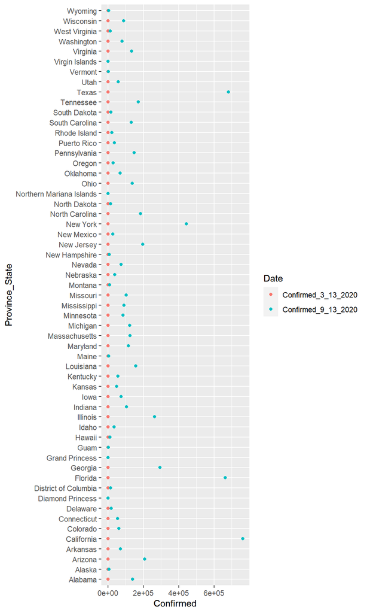

```r
# Convert the joined table to long format -
Confirmed_State_3_13_9_13_joined_long <- Confirmed_State_3_13_9_13_joined %>%
  pivot_longer(-c(Province_State), names_to = "Date", values_to = "Confirmed")
# names_to argument is for the keys for the categorical variable (all but state names) while
# values_to argument is for the values of those keys (Confirmed cases for each date).

# Now, plot the data in a scatterplot. Adjust the figure size in Rmd using fig.width and
# fig.height in the R chunk declaration ({r, fig.width = 5, fig.height = 10})
ggplot(Confirmed_State_3_13_9_13_joined_long, aes(x = Confirmed, y = Province_State)) +
  geom_point(aes(color = Date))
```